# Assignment - Week 05

Yara Roth

2026-03-25

# Setup

```r
suppressPackageStartupMessages({
  library(GenomicRanges)
  library(SummarizedExperiment)
  library(edgeR) # differential gene expression using neg.bin stats
  library(epiwraps)
  library(ggplot2)
  library(sechm) # for plotting (features*samples) heatmaps
})

library(rstudioapi)
setwd(dirname(rstudioapi::getActiveDocumentContext()$path))
```

# Download

Our data is already available as SummarizedExperiment object, meaning the peaks were already called and counted (no need for peak calling).

```r
dir.create("data")
download.file("https://ethz-ins.org/content/mouse_mm38_hippocampus.peakCounts.SE.rds", "data/hippo_peaks.SE.rds")

se <- readRDS("data/hippo_peaks.SE.rds")
head(se)
```

```
## class: RangedSummarizedExperiment
## dim: 6 12
## metadata(0):
## assays(1): counts
## rownames: NULL
## rowData names(0):
## colnames(12): Control_female_GSM6041841.bam
##   Control_female_GSM6041842.bam ... FSS_male_GSM6041857.bam
##   FSS_male_GSM6041858.bam
## colData names(1): depth
```

```r
colData(se)
```

```
## DataFrame with 12 rows and 1 column
##                                   depth
##                               <numeric>
## Control_female_GSM6041841.bam  73170149
## Control_female_GSM6041842.bam  93995034
## Control_female_GSM6041843.bam  40167775
## Control_male_GSM6041844.bam    70491005
## Control_male_GSM6041845.bam    84985977
## ...                                 ...
## FSS_female_GSM6041854.bam      73674456
## FSS_female_GSM6041855.bam      49285912
## FSS_male_GSM6041856.bam        82385764
## FSS_male_GSM6041857.bam        68623011
## FSS_male_GSM6041858.bam        81801232
```

# Differential Analysis

We will first add a new column to our dataframe attributing the condition (FSS/Control) and sex (male/female).

```r
se$condition <- ifelse(grepl("Control", colnames(se)), "Control", "FSS")
se$sex <- ifelse(grepl("female", colnames(se)), "female", "male")

colData(se)
```

```
## DataFrame with 12 rows and 3 columns
##                                   depth   condition         sex
##                               <numeric> <character> <character>
## Control_female_GSM6041841.bam  73170149     Control      female
## Control_female_GSM6041842.bam  93995034     Control      female
## Control_female_GSM6041843.bam  40167775     Control      female
## Control_male_GSM6041844.bam    70491005     Control        male
## Control_male_GSM6041845.bam    84985977     Control        male
## ...                                 ...         ...         ...
## FSS_female_GSM6041854.bam      73674456         FSS      female
## FSS_female_GSM6041855.bam      49285912         FSS      female
## FSS_male_GSM6041856.bam        82385764         FSS        male
## FSS_male_GSM6041857.bam        68623011         FSS        male
## FSS_male_GSM6041858.bam        81801232         FSS        male
```

For the heatmap generation we’ll get an error because `se`has no rownames, so we’ll attribute rownames:

```r
rownames(se) <- as.character(rowRanges(se))
head(rownames(se))
```

```
## [1] "1:3012609-3012858" "1:3094941-3095190" "1:3113634-3113883"
## [4] "1:3119522-3119771" "1:3119880-3120129" "1:3120379-3120628"
```

## DE for condition (FSS vs Control) - controlling for sex

As we have both the condition and sex in our data, we should ideally use the glm apporach to account for sex or condition as a covariate.  
For the differential analysis on condition, we account for sex as a covariate.

```r
dds <- edgeR::DGEList(assay(se), group=se$condition)
mm <- model.matrix(~condition + sex, data=as.data.frame(colData(se)))

# as we can use TMM normalization:
dds <- edgeR::calcNormFactors(dds)
dds <- estimateDisp(dds, mm)
fit <- glmQLFit(dds, mm)
et_condition <- as.data.frame(topTags(glmQLFTest(fit, coef=2), Inf))

head(et_condition)
```

```
##                           logFC   logCPM        F       PValue       FDR
## 1:190561376-190561625  2.901536 5.569378 23.94762 5.367023e-05 0.9998368
## 1:72830161-72830410    2.821628 4.138278 16.15287 4.457507e-04 0.9998368
## 1:9851493-9851742      2.074731 5.877499 16.44225 4.656935e-04 0.9998368
## X:19311392-19311641   -2.709181 5.380703 15.98062 5.216453e-04 0.9998368
## X:47641251-47641500   -3.455016 3.757707 13.90009 8.148733e-04 0.9998368
## X:57787670-57787919   -4.015213 5.949095 14.30343 8.232601e-04 0.9998368
```

To quickly assess our results we can look at the following volcano plot:

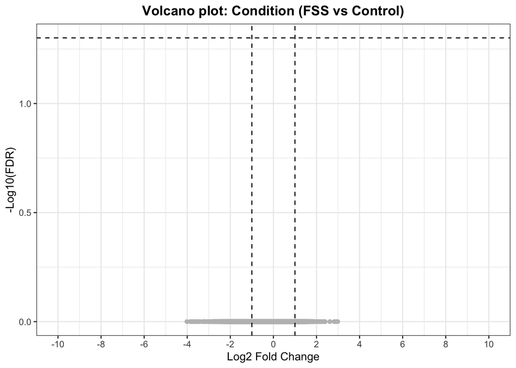

```r
ggplot(et_condition, aes(logFC, -log10(FDR))) +
  geom_point(aes(color = ifelse(-log10(FDR) > -log10(0.05) & abs(logFC) > log2(2),
                                 ifelse(logFC > 0, "red", "blue"),
                                 "grey"))) +
  geom_hline(yintercept = -log10(0.05),
             linetype = "dashed") +
  geom_vline(xintercept = c(log2(0.5), log2(2)),
             linetype = "dashed") +
  scale_x_continuous(breaks = seq(-10, 10, 2),
                     limits = c(-10, 10)) +
  scale_color_identity() +
  labs(title = "Volcano plot: Condition (FSS vs Control)",
       x = "Log2 Fold Change",
       y = "-Log10(FDR)") +
  theme_bw() +
  theme(plot.title = element_text(hjust = 0.5, face = "bold"))
```

Now we will look the the 10 most significant regions:

```r
top10_condition <- head(et_condition, 10)
top10_condition
```

```
##                           logFC   logCPM        F       PValue       FDR
## 1:190561376-190561625  2.901536 5.569378 23.94762 5.367023e-05 0.9998368
## 1:72830161-72830410    2.821628 4.138278 16.15287 4.457507e-04 0.9998368
## 1:9851493-9851742      2.074731 5.877499 16.44225 4.656935e-04 0.9998368
## X:19311392-19311641   -2.709181 5.380703 15.98062 5.216453e-04 0.9998368
## X:47641251-47641500   -3.455016 3.757707 13.90009 8.148733e-04 0.9998368
## X:57787670-57787919   -4.015213 5.949095 14.30343 8.232601e-04 0.9998368
## X:139839112-139839361 -3.588652 3.383900 13.11690 1.051976e-03 0.9998368
## X:167164806-167165055  2.045768 4.909977 13.74880 1.083813e-03 0.9998368
## 1:182090015-182090264  1.790530 7.090529 13.10050 1.389088e-03 0.9998368
## 1:119219696-119219945  2.164670 4.310488 12.81365 1.461153e-03 0.9998368
```

If we have a logFC > 0, means that we have a more accessible chromatin region in FSS animals compared to the control. LogFC < 0 are less accessible in FSS animals.  
Importantly none of the top 10 significant regions are statistically different compared to the control. Maybe this would look different if we don’t control for sex (see `next section`).

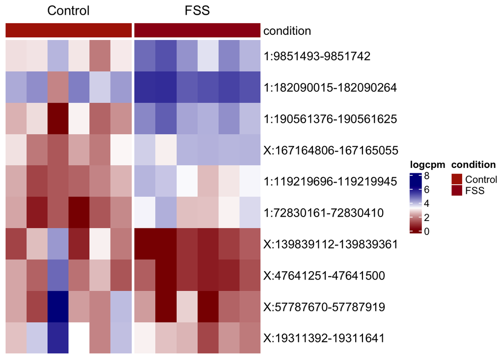

```r
# place the normalized data back into our original se object
assay(se, "logcpm") <- log1p(cpm(dds))
# then we will plot the 10 most significant regions
topRegions <- head(row.names(et_condition),10)

# i added a different color code
metadata(se)$hmcols <- c("darkred", "white", "darkblue")
sechm(se, topRegions, gaps_at="condition")
```

Interestingly, in the heatmap we see a higher inter-sample variability in between the control samples compared to the FSS.  
Maybe in the control animals these generally show a higher variablity. The stress could induce a convergent epigenetic response > upregulating relevant genes, leading to a reduced inter-sample variablity.

### DE for condition (FSS vs Control) - NOT controlling for sex

I also wanted to see whether our DE looks different if we do not control for sex (although I think the right way would be to do so).

```r
dds <- edgeR::DGEList(assay(se), group=se$condition)
dds <- edgeR::calcNormFactors(dds)

dds <- edgeR::estimateDisp(dds)
```

```
## Using classic mode.
```

```r
et <- as.data.frame(topTags(exactTest(dds), Inf))
head(et)
```

```
##                           logFC   logCPM       PValue        FDR
## 1:190561376-190561625  2.956602 5.568769 2.042974e-06 0.04220785
## 1:176712487-176712736 -5.547326 7.661587 3.527416e-05 0.12814460
## X:134830585-134830834 -5.303580 6.889311 4.895397e-05 0.12814460
## 1:125542384-125542633 -4.828255 8.216940 5.221790e-05 0.12814460
## 1:38248121-38248370   -5.984659 8.519979 5.504660e-05 0.12814460
## 1:72830161-72830410    2.858099 4.136854 5.892303e-05 0.12814460
```

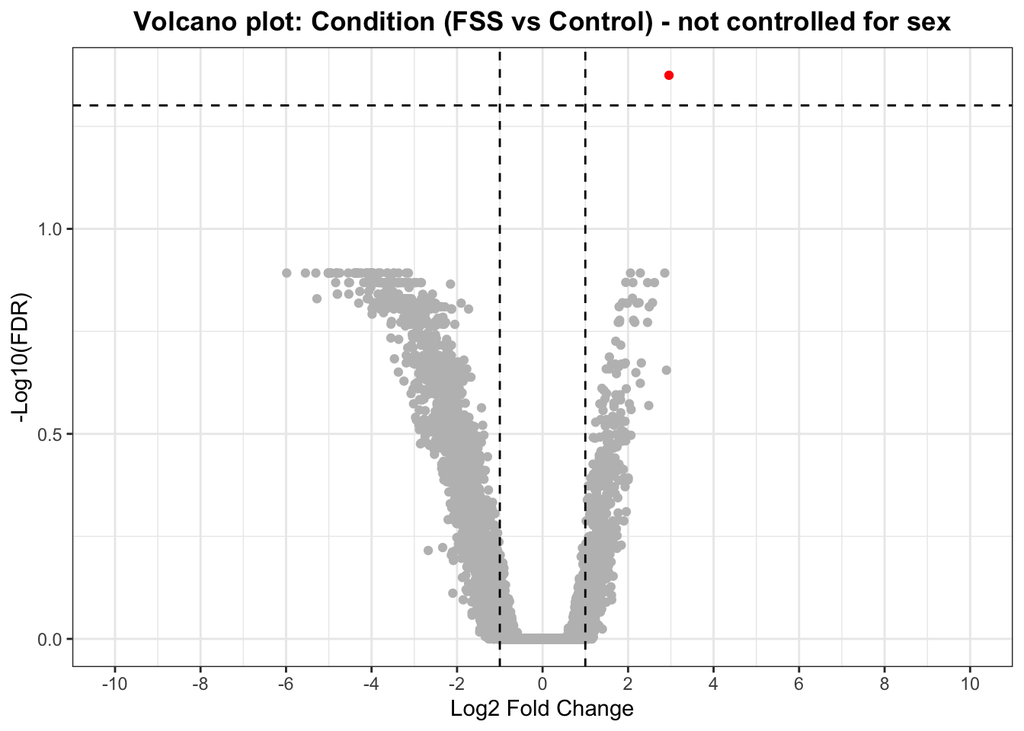

```r
ggplot(et, aes(logFC, -log10(FDR))) +
  geom_point(aes(color = ifelse(-log10(FDR) > -log10(0.05) & abs(logFC) > log2(2),
                                 ifelse(logFC > 0, "red", "blue"),
                                 "grey"))) +
  geom_hline(yintercept = -log10(0.05),
             linetype = "dashed") +
  geom_vline(xintercept = c(log2(0.5), log2(2)),
             linetype = "dashed") +
  scale_x_continuous(breaks = seq(-10, 10, 2),
                     limits = c(-10, 10)) +
  scale_color_identity() +
  labs(title = "Volcano plot: Condition (FSS vs Control) - not controlled for sex",
       x = "Log2 Fold Change",
       y = "-Log10(FDR)") +
  theme_bw() +
  theme(plot.title = element_text(hjust = 0.5, face = "bold"))
```

```r
top10_condition_nocov <- head(et, 10)
top10_condition_nocov
```

```
##                           logFC   logCPM       PValue        FDR
## 1:190561376-190561625  2.956602 5.568769 2.042974e-06 0.04220785
## 1:176712487-176712736 -5.547326 7.661587 3.527416e-05 0.12814460
## X:134830585-134830834 -5.303580 6.889311 4.895397e-05 0.12814460
## 1:125542384-125542633 -4.828255 8.216940 5.221790e-05 0.12814460
## 1:38248121-38248370   -5.984659 8.519979 5.504660e-05 0.12814460
## 1:72830161-72830410    2.858099 4.136854 5.892303e-05 0.12814460
## 1:21635475-21635724   -4.385188 6.854042 6.315310e-05 0.12814460
## 1:54734997-54735246   -4.283877 7.508608 7.465340e-05 0.12814460
## 1:159451546-159451795 -4.818518 5.728855 7.652971e-05 0.12814460
## X:16998632-16998881   -4.973348 7.122513 9.182810e-05 0.12814460
```

And now indeed we have one region that is significantly more accessible in the stressed samples compared to the controls. But it is important to note that this effect disappears when we control for sex (see `DE for condition (FSS vs Control) - controlling for sex`).

## DE for sex (male vs female)

For the differential analysis on sex, we account for condition as a covariate.

```r
dds <- edgeR::DGEList(assay(se), group=se$sex)
mm <- model.matrix(~sex + condition, data=as.data.frame(colData(se)))

# as we can use TMM normalization:
dds <- edgeR::calcNormFactors(dds)
dds <- estimateDisp(dds, mm)
fit <- glmQLFit(dds, mm)
et_sex <- as.data.frame(topTags(glmQLFTest(fit, coef=2), Inf))

head(et_sex)
```

```
##                         logFC   logCPM         F       PValue          FDR
## Y:1010447-1010696    6.873576 6.682913 140.36781 1.164821e-12 2.406521e-08
## Y:1010170-1010419    6.896945 6.814142 104.60216 3.593172e-11 3.711746e-07
## Y:809076-809325      6.420077 5.522900  95.71197 7.533393e-11 5.187997e-07
## X:75734949-75735198 -4.959174 7.722119 111.02515 1.930071e-10 9.968818e-07
## X:75729899-75730148 -4.920744 7.416561 106.96981 2.718443e-10 1.120920e-06
## X:50583794-50584043 -5.449459 6.233174  97.49402 3.255333e-10 1.120920e-06
```

To quickly assess our results we can look at the following volcano plot:

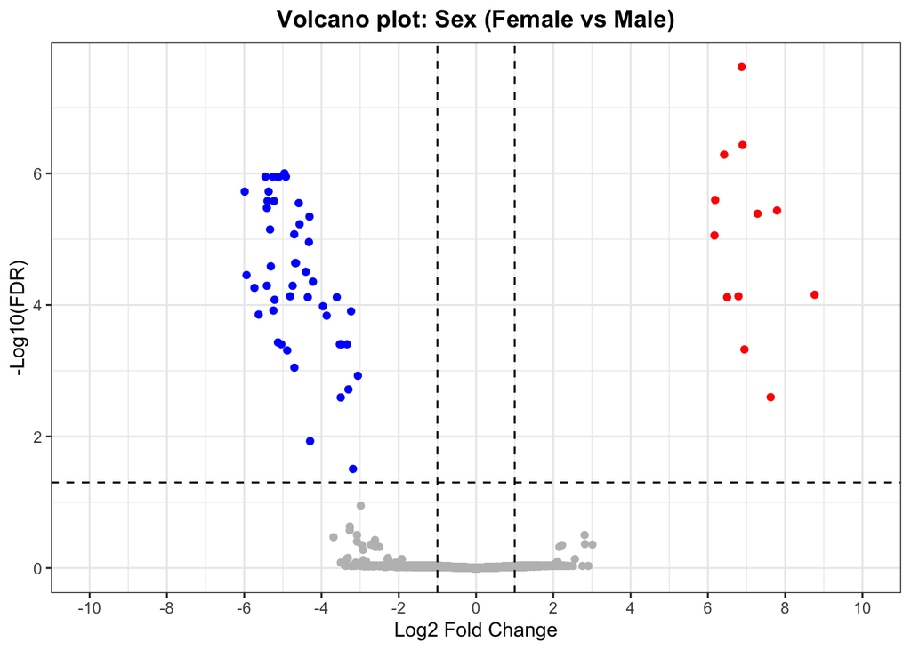

```r
ggplot(et_sex, aes(logFC, -log10(FDR))) +
  geom_point(aes(color = ifelse(-log10(FDR) > -log10(0.05) & abs(logFC) > log2(2),
                                 ifelse(logFC > 0, "red", "blue"),
                                 "grey"))) +
  geom_hline(yintercept = -log10(0.05),
             linetype = "dashed") +
  geom_vline(xintercept = c(log2(0.5), log2(2)),
             linetype = "dashed") +
  scale_x_continuous(breaks = seq(-10, 10, 2),
                     limits = c(-10, 10)) +
  scale_color_identity() +
  labs(title = "Volcano plot: Sex (Female vs Male)",
       x = "Log2 Fold Change",
       y = "-Log10(FDR)") +
  theme_bw() +
  theme(plot.title = element_text(hjust = 0.5, face = "bold"))
```

```r
top10_sex <- head(et_sex, 10)
top10_sex
```

```
##                         logFC   logCPM         F       PValue          FDR
## Y:1010447-1010696    6.873576 6.682913 140.36781 1.164821e-12 2.406521e-08
## Y:1010170-1010419    6.896945 6.814142 104.60216 3.593172e-11 3.711746e-07
## Y:809076-809325      6.420077 5.522900  95.71197 7.533393e-11 5.187997e-07
## X:75734949-75735198 -4.959174 7.722119 111.02515 1.930071e-10 9.968818e-07
## X:75729899-75730148 -4.920744 7.416561 106.96981 2.718443e-10 1.120920e-06
## X:50583794-50584043 -5.449459 6.233174  97.49402 3.255333e-10 1.120920e-06
## X:75744534-75744783 -5.260131 7.845101 102.68112 4.104001e-10 1.124853e-06
## X:75749391-75749640 -5.101169 8.265080 102.45521 4.358550e-10 1.124853e-06
## X:50590734-50590983 -5.138911 6.574850  97.83920 4.900132e-10 1.124853e-06
## X:50600341-50600590 -5.367367 7.375748  93.12743 9.763968e-10 1.887117e-06
```

Here we have several regions that are significantly different accessible in between females and males.

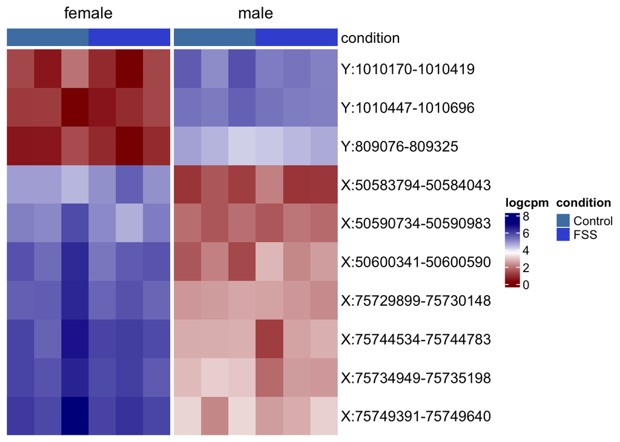

```r
# place the normalized data back into our original se object
assay(se, "logcpm") <- log1p(cpm(dds))
# then we will plot the 10 most significant regions
topRegions <- head(row.names(et_sex),10)

# then I added a different color code
metadata(se)$hmcols <- c("darkred", "white", "darkblue")
sechm(se, topRegions, gaps_at="sex")
```

The differential analysis on sex reveals clear changes in chromatin accessibility that are located on either X and Y chromosome, which biologically makes a lot of sense. One could additionally filter out the regions located on the X or Y chromosome to look at the differences of autosome chromosomes.